# Set de Ejercicios 5

Daniel Juarez Bautista

08/05/2020

# Carga los datos

```r
library(tidyverse)
library(sf)
library(scico)
library(gganimate)
library(gifski)
library(dplyr)
library(transformr)

# Datos de RIAA
# https://www.riaa.com/u-s-sales-database/
riaa <- read_csv("riaa.csv") %>%
  # Solo observa este tipo de ventas
  filter(Format %in% c("LP/EP", "Cassette", "CD", "Download Album",
                       "Download Single", "Ringtones & Ringbacks",
                       "On-Demand Streaming (Ad-Supported)", "Paid Subscription")) %>%
  # Observa las ventas ajustadas por inflación (los otros valores son para ventas no ajustadas por inflación   # y unidades vendidas)
  filter(Metric == "Value (Adjusted)") %>%
  mutate(Value = ifelse(is.na(Value), 0, Value))

# Carga datos sobre usuarios de internet
internet_users <- read_csv("share-of-individuals-using-the-internet-1990-2015.csv") %>%
  # Renombra la columna para el código de país a ISO_A3 para que conincida con el shapefile de Natural Earth
  rename(users = `Individuals using the Internet (% of population) (% of population)`,
         ISO_A3 = Code)

# Carga el shapefile del mundo de Natural Earth
# https://www.naturalearthdata.com/downloads/110m-cultural-vectors/
world_shapes <- st_read("ne_110m_admin_0_countries/ne_110m_admin_0_countries.shp",
                        stringsAsFactors = FALSE)
# Carga otros shapefiles si los necesitas
```

# Parte 1: RIAA ganancias en música

Crea tu propia visualización aquí.

Nota: los valores están ajustados por la inflación y representan dólares en 2017. Trata de usar otros colores que no sean el default y considera agregar etiquetas directamente al gráfico en vez de usar una leyenda.

Cuenta una historia sobre lo que está pasando en este gráfico. Interprétalo.

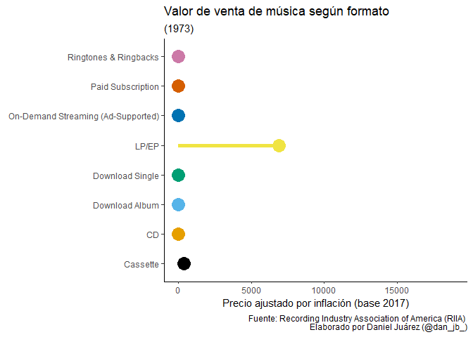

```r
cbp2 <- c("#000000", "#E69F00", "#56B4E9", "#009E73",
          "#F0E442", "#0072B2", "#D55E00", "#CC79A7")

gif <- ggplot(riaa, aes(x=Format, y=Value, colour=Format)) +
  geom_pointrange(aes(ymin=0, ymax=Value), fatten = 3, size = 2) +
  guides(colour=FALSE) +
  theme_classic() +
  scale_colour_manual(values=cbp2) +
  coord_flip() +
  labs(x = NULL,
       y = "Precio ajustado por inflación (base 2017)",
       title = "Valor de venta de música según formato",
       subtitle = "({as.integer(frame_time)})",
       caption = "Fuente: Recording Industry Association of America (RIIA) \n Elaborado por Daniel Juárez (@dan_jb_)") +
  transition_time(Year) +
  ease_aes("linear")
animate(gif, nframes = 50, duration = 15)
```

En este gráfico, observamos la evolución del valor de venta de música según los formatos. Los datos van de 1973 a 2017 por lo que durante la mayoría de periodos los formatos más modernos como streaming de música y suscripciones de pago tienen un valor de cero.

Resulta interesante el boom que experimenta el valor de los CD a partir de mediados de los 80. Sin embargo, este boom se ve cortado por las nuevas tecnologías que comienzan a tener mayor presencia a partir de 2006, año en el que se funda Spotify. A partir de ese año comienzan a surgir competidores como Rdio y Apple Music.

Es importante recalcar que estas tecnologías de streaming y suscripciones de pago como Spotify y Apple Music surgieron a finales de la primera década del siglo XXI por lo que no contamos con muchos años de información sobre estas tecnologías. No obstante, la tendencia a la baja de los discos y la tendencia a la alta de las nuevas tecnologías es evidente.

# Parte 2: Mapa del Mundo

Produce un mapa de usuarios de internet con `ggplot() + geom_sf()`. Cuenta una historia sobre lo que pasa en el mapa. Interprétalo.

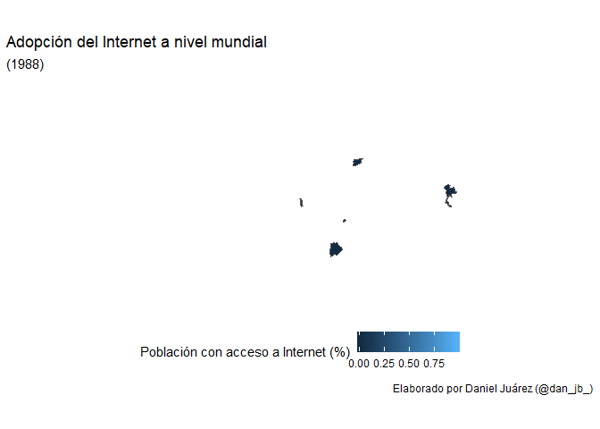

```r
# left_join toma dos bases de datos y las combina, basado en una columna común.
# (en este caso ISO_A3)
users_map <- world_shapes %>%
  left_join(internet_users, by = "ISO_A3") %>%
  filter(ISO_A3 != "ATA", Year>=1988) %>%
  mutate(users = users/100)

map <- ggplot() +
  geom_sf(data =users_map, aes(fill = users)) +
  coord_sf(crs = 4326, datum = NA) +
  theme_classic() +
  labs(title = "Adopción del Internet a nivel mundial",
       subtitle = "({as.integer(frame_time)})",
       caption = "Elaborado por Daniel Juárez (@dan_jb_)") +
  labs(fill="Población con acceso a Internet (%)") +
  theme(legend.position="bottom") +
  transition_time(Year)
animate(map, nframes = 100, duration = 20)
```

En este mapa observamos la evolución del acceso a internet a nivel mundial desde 1988 hasta 2015. Esto permite visualizar el boom de la globalización y el avance tecnológico del siglo XXI. Una de las desventajas de esta visualización que no logré corregir es que no hay datos para todos los años para todos los países por lo que algunos años pueden distorsionar el mapa. Sin embargo, el cambio de la tonalidad a nivel mundial se puede percibir.

Especificaciones interesantes de este mapa son la rápida adopción del internet en norteamérica y la poca o lenta adopción en África. Esto nos permitiría complementar análisis sobre desigualdad entre países.